Skip to content

# Low-Level Interface

While the functions `bart()` and `bcf()` provide simple and performant interfaces for supervised learning / causal inference, `stochtree` also offers access to many of the "low-level" data structures that are typically implemented in C++. This low-level interface is not designed for performance or even simplicity --- rather the intent is to provide a "prototype" interface to the C++ code that doesn't require modifying any C++.

To illustrate when such a prototype interface might be useful, consider that that "classic" BART algorithm is essentially a Metropolis-within-Gibbs sampler, in which the forest is sampled by MCMC, conditional on all of the other model parameters, and then the model parameters are updated by Gibbs.

While the algorithm itself is conceptually simple, much of the core computation is carried out in low-level languages such as C or C++ because of the tree data structures. As a result, any changes to this algorithm, such as supporting heteroskedasticity and categorical outcomes (Murray 2021) or causal effect estimation (Hahn et al 2020) require modifying low-level code.

## Scenario 1: Supervised Learning

Load necessary libraries

```python
import matplotlib.pyplot as plt
import numpy as np
import pandas as pd
import seaborn as sns

from stochtree import (
    RNG,
    Dataset,
    Forest,
    ForestContainer,
    ForestSampler,
    GlobalVarianceModel,
    LeafVarianceModel,
    Residual,
    ForestModelConfig,
    GlobalModelConfig,
)
```

import matplotlib.pyplot as plt import numpy as np import pandas as pd import seaborn as sns from stochtree import ( RNG, Dataset, Forest, ForestContainer, ForestSampler, GlobalVarianceModel, LeafVarianceModel, Residual, ForestModelConfig, GlobalModelConfig, )

Generate sample data

```python
# RNG
random_seed = 1234
rng = np.random.default_rng(random_seed)

# Generate covariates and basis
n = 500
p_X = 10
p_W = 1
X = rng.uniform(0, 1, (n, p_X))
W = rng.uniform(0, 1, (n, p_W))

# Define the outcome mean function
def outcome_mean(X, W):
    return np.where(
        (X[:, 0] >= 0.0) & (X[:, 0] < 0.25),
        -7.5 * W[:, 0],
        np.where(
            (X[:, 0] >= 0.25) & (X[:, 0] < 0.5),
            -2.5 * W[:, 0],
            np.where((X[:, 0] >= 0.5) & (X[:, 0] < 0.75), 2.5 * W[:, 0], 7.5 * W[:, 0]),
        ),
    )


# Generate outcome
epsilon = rng.normal(0, 1, n)
y = outcome_mean(X, W) + epsilon

# Standardize outcome
y_bar = np.mean(y)
y_std = np.std(y)
resid = (y - y_bar) / y_std
```

# RNG random_seed = 1234 rng = np.random.default_rng(random_seed) # Generate covariates and basis n = 500 p_X = 10 p_W = 1 X = rng.uniform(0, 1, (n, p_X)) W = rng.uniform(0, 1, (n, p_W)) # Define the outcome mean function def outcome_mean(X, W): return np.where( (X[:, 0] >= 0.0) & (X[:, 0] < 0.25), -7.5 * W[:, 0], np.where( (X[:, 0] >= 0.25) & (X[:, 0] < 0.5), -2.5 * W[:, 0], np.where((X[:, 0] >= 0.5) & (X[:, 0] < 0.75), 2.5 * W[:, 0], 7.5 * W[:, 0]), ), ) # Generate outcome epsilon = rng.normal(0, 1, n) y = outcome_mean(X, W) + epsilon # Standardize outcome y_bar = np.mean(y) y_std = np.std(y) resid = (y - y_bar) / y_std

Set some sampling parameters

```python
alpha = 0.9
beta = 1.25
min_samples_leaf = 1
max_depth = -1
num_trees = 100
cutpoint_grid_size = 100
global_variance_init = 1.0
tau_init = 0.5
leaf_prior_scale = np.array([[tau_init]], order="C")
a_global = 4.0
b_global = 2.0
a_leaf = 2.0
b_leaf = 0.5
leaf_regression = True
feature_types = np.repeat(0, p_X).astype(int)  # 0 = numeric
var_weights = np.repeat(1 / p_X, p_X)
if not leaf_regression:
    leaf_model = 0
    leaf_dimension = 1
elif leaf_regression and p_W == 1:
    leaf_model = 1
    leaf_dimension = 1
else:
    leaf_model = 2
    leaf_dimension = p_W
```

alpha = 0.9 beta = 1.25 min_samples_leaf = 1 max_depth = -1 num_trees = 100 cutpoint_grid_size = 100 global_variance_init = 1.0 tau_init = 0.5 leaf_prior_scale = np.array([[tau_init]], order="C") a_global = 4.0 b_global = 2.0 a_leaf = 2.0 b_leaf = 0.5 leaf_regression = True feature_types = np.repeat(0, p_X).astype(int) # 0 = numeric var_weights = np.repeat(1 / p_X, p_X) if not leaf_regression: leaf_model = 0 leaf_dimension = 1 elif leaf_regression and p_W == 1: leaf_model = 1 leaf_dimension = 1 else: leaf_model = 2 leaf_dimension = p_W

Convert data from numpy to `StochTree` representation

```python
# Dataset (covariates and basis)
dataset = Dataset()
dataset.add_covariates(X)
dataset.add_basis(W)

# Residual
residual = Residual(resid)
```

# Dataset (covariates and basis) dataset = Dataset() dataset.add_covariates(X) dataset.add_basis(W) # Residual residual = Residual(resid)

Initialize tracking and sampling classes

```python
forest_container = ForestContainer(num_trees, W.shape[1], False, False)
active_forest = Forest(num_trees, W.shape[1], False, False)
global_model_config = GlobalModelConfig(global_error_variance=global_variance_init)
forest_model_config = ForestModelConfig(
    num_trees=num_trees,
    num_features=p_X,
    num_observations=n,
    feature_types=feature_types,
    variable_weights=var_weights,
    leaf_dimension=1,
    alpha=alpha,
    beta=beta,
    min_samples_leaf=min_samples_leaf,
    max_depth=max_depth,
    leaf_model_type=leaf_model,
    leaf_model_scale=leaf_prior_scale,
    cutpoint_grid_size=cutpoint_grid_size,
)
forest_sampler = ForestSampler(
    dataset, global_model_config, forest_model_config
)
cpp_rng = RNG(random_seed)
global_var_model = GlobalVarianceModel()
leaf_var_model = LeafVarianceModel()

# Initialize the leaves of each tree in the mean forest
if leaf_regression:
    forest_init_val = np.repeat(0.0, W.shape[1])
else:
    forest_init_val = np.array([0.0])
forest_sampler.prepare_for_sampler(
    dataset,
    residual,
    active_forest,
    leaf_model,
    forest_init_val,
)
```

forest_container = ForestContainer(num_trees, W.shape[1], False, False) active_forest = Forest(num_trees, W.shape[1], False, False) global_model_config = GlobalModelConfig(global_error_variance=global_variance_init) forest_model_config = ForestModelConfig( num_trees=num_trees, num_features=p_X, num_observations=n, feature_types=feature_types, variable_weights=var_weights, leaf_dimension=1, alpha=alpha, beta=beta, min_samples_leaf=min_samples_leaf, max_depth=max_depth, leaf_model_type=leaf_model, leaf_model_scale=leaf_prior_scale, cutpoint_grid_size=cutpoint_grid_size, ) forest_sampler = ForestSampler( dataset, global_model_config, forest_model_config ) cpp_rng = RNG(random_seed) global_var_model = GlobalVarianceModel() leaf_var_model = LeafVarianceModel() # Initialize the leaves of each tree in the mean forest if leaf_regression: forest_init_val = np.repeat(0.0, W.shape[1]) else: forest_init_val = np.array([0.0]) forest_sampler.prepare_for_sampler( dataset, residual, active_forest, leaf_model, forest_init_val, )

Prepare to run the sampler

```python
num_warmstart = 10
num_mcmc = 100
num_samples = num_warmstart + num_mcmc
global_var_samples = np.concatenate(
    (np.array([global_variance_init]), np.repeat(0, num_samples))
)
leaf_scale_samples = np.concatenate((np.array([tau_init]), np.repeat(0, num_samples)))
```

num_warmstart = 10 num_mcmc = 100 num_samples = num_warmstart + num_mcmc global_var_samples = np.concatenate( (np.array([global_variance_init]), np.repeat(0, num_samples)) ) leaf_scale_samples = np.concatenate((np.array([tau_init]), np.repeat(0, num_samples)))

Run the "grow-from-root" (XBART) sampler

```python
for i in range(num_warmstart):
    forest_sampler.sample_one_iteration(
        forest_container,
        active_forest,
        dataset,
        residual,
        cpp_rng,
        global_model_config,
        forest_model_config,
        True,
        True,
    )
    global_var_samples[i + 1] = global_var_model.sample_one_iteration(
        residual, cpp_rng, a_global, b_global
    )
    leaf_scale_samples[i + 1] = leaf_var_model.sample_one_iteration(
        active_forest, cpp_rng, a_leaf, b_leaf
    )
    leaf_prior_scale[0, 0] = leaf_scale_samples[i + 1]
```

for i in range(num_warmstart): forest_sampler.sample_one_iteration( forest_container, active_forest, dataset, residual, cpp_rng, global_model_config, forest_model_config, True, True, ) global_var_samples[i + 1] = global_var_model.sample_one_iteration( residual, cpp_rng, a_global, b_global ) leaf_scale_samples[i + 1] = leaf_var_model.sample_one_iteration( active_forest, cpp_rng, a_leaf, b_leaf ) leaf_prior_scale[0, 0] = leaf_scale_samples[i + 1]

Run the MCMC (BART) sampler, initialized at the last XBART sample

```python
for i in range(num_warmstart, num_samples):
    forest_sampler.sample_one_iteration(
        forest_container,
        active_forest,
        dataset,
        residual,
        cpp_rng,
        global_model_config,
        forest_model_config,
        True,
        False,
    )
    global_var_samples[i + 1] = global_var_model.sample_one_iteration(
        residual, cpp_rng, a_global, b_global
    )
    leaf_scale_samples[i + 1] = leaf_var_model.sample_one_iteration(
        active_forest, cpp_rng, a_leaf, b_leaf
    )
    leaf_prior_scale[0, 0] = leaf_scale_samples[i + 1]
```

for i in range(num_warmstart, num_samples): forest_sampler.sample_one_iteration( forest_container, active_forest, dataset, residual, cpp_rng, global_model_config, forest_model_config, True, False, ) global_var_samples[i + 1] = global_var_model.sample_one_iteration( residual, cpp_rng, a_global, b_global ) leaf_scale_samples[i + 1] = leaf_var_model.sample_one_iteration( active_forest, cpp_rng, a_leaf, b_leaf ) leaf_prior_scale[0, 0] = leaf_scale_samples[i + 1]

Extract mean function and error variance posterior samples

```python
# Forest predictions
forest_preds = forest_container.predict(dataset)
forest_preds = forest_preds * y_std + y_bar
forest_preds_gfr = forest_preds[:, :num_warmstart]
forest_preds_mcmc = forest_preds[:, num_warmstart:num_samples]

# Global error variance
sigma2_samples = global_var_samples * y_std * y_std
sigma2_samples_gfr = sigma2_samples[:num_warmstart]
sigma2_samples_mcmc = sigma2_samples[num_warmstart:num_samples]
```

# Forest predictions forest_preds = forest_container.predict(dataset) forest_preds = forest_preds * y_std + y_bar forest_preds_gfr = forest_preds[:, :num_warmstart] forest_preds_mcmc = forest_preds[:, num_warmstart:num_samples] # Global error variance sigma2_samples = global_var_samples * y_std * y_std sigma2_samples_gfr = sigma2_samples[:num_warmstart] sigma2_samples_mcmc = sigma2_samples[num_warmstart:num_samples]

Inspect the GFR (XBART) samples

```python
forest_pred_avg_gfr = forest_preds_gfr.mean(axis=1, keepdims=True)
forest_pred_df_gfr = pd.DataFrame(
    np.concatenate((np.expand_dims(y, axis=1), forest_pred_avg_gfr), axis=1),
    columns=["True y", "Average predicted y"],
)
sns.scatterplot(data=forest_pred_df_gfr, x="True y", y="Average predicted y")
plt.axline((0, 0), slope=1, color="black", linestyle=(0, (3, 3)))
plt.show()
```

forest_pred_avg_gfr = forest_preds_gfr.mean(axis=1, keepdims=True) forest_pred_df_gfr = pd.DataFrame( np.concatenate((np.expand_dims(y, axis=1), forest_pred_avg_gfr), axis=1), columns=["True y", "Average predicted y"], ) sns.scatterplot(data=forest_pred_df_gfr, x="True y", y="Average predicted y") plt.axline((0, 0), slope=1, color="black", linestyle=(0, (3, 3))) plt.show()

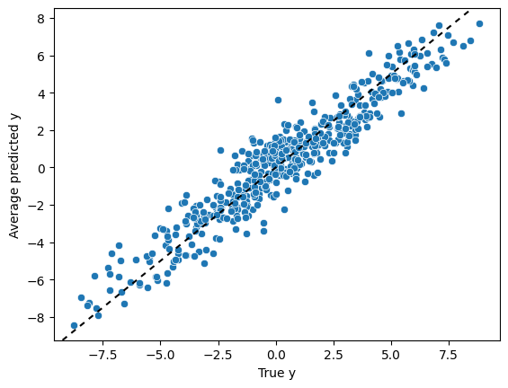

```python
sigma_df_gfr = pd.DataFrame(
    np.concatenate(
        (
            np.expand_dims(np.arange(num_warmstart), axis=1),
            np.expand_dims(sigma2_samples_gfr, axis=1),
        ),
        axis=1,
    ),
    columns=["Sample", "Sigma^2"],
)
sns.scatterplot(data=sigma_df_gfr, x="Sample", y="Sigma^2")
plt.show()
```

sigma_df_gfr = pd.DataFrame( np.concatenate( ( np.expand_dims(np.arange(num_warmstart), axis=1), np.expand_dims(sigma2_samples_gfr, axis=1), ), axis=1, ), columns=["Sample", "Sigma^2"], ) sns.scatterplot(data=sigma_df_gfr, x="Sample", y="Sigma^2") plt.show()

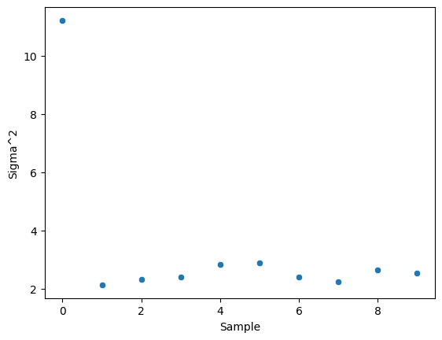

Inspect the MCMC (BART) samples

```python
forest_pred_avg_mcmc = forest_preds_mcmc.mean(axis=1, keepdims=True)
forest_pred_df_mcmc = pd.DataFrame(
    np.concatenate((np.expand_dims(y, axis=1), forest_pred_avg_mcmc), axis=1),
    columns=["True y", "Average predicted y"],
)
sns.scatterplot(data=forest_pred_df_mcmc, x="True y", y="Average predicted y")
plt.axline((0, 0), slope=1, color="black", linestyle=(0, (3, 3)))
plt.show()
```

forest_pred_avg_mcmc = forest_preds_mcmc.mean(axis=1, keepdims=True) forest_pred_df_mcmc = pd.DataFrame( np.concatenate((np.expand_dims(y, axis=1), forest_pred_avg_mcmc), axis=1), columns=["True y", "Average predicted y"], ) sns.scatterplot(data=forest_pred_df_mcmc, x="True y", y="Average predicted y") plt.axline((0, 0), slope=1, color="black", linestyle=(0, (3, 3))) plt.show()

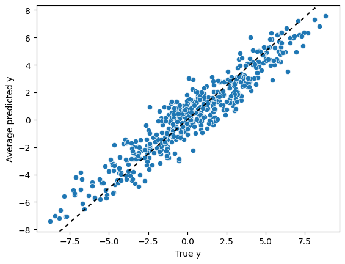

```python
sigma_df_mcmc = pd.DataFrame(
    np.concatenate(
        (
            np.expand_dims(np.arange(num_samples - num_warmstart), axis=1),
            np.expand_dims(sigma2_samples_mcmc, axis=1),
        ),
        axis=1,
    ),
    columns=["Sample", "Sigma^2"],
)
sns.scatterplot(data=sigma_df_mcmc, x="Sample", y="Sigma^2")
plt.show()
```

sigma_df_mcmc = pd.DataFrame( np.concatenate( ( np.expand_dims(np.arange(num_samples - num_warmstart), axis=1), np.expand_dims(sigma2_samples_mcmc, axis=1), ), axis=1, ), columns=["Sample", "Sigma^2"], ) sns.scatterplot(data=sigma_df_mcmc, x="Sample", y="Sigma^2") plt.show()

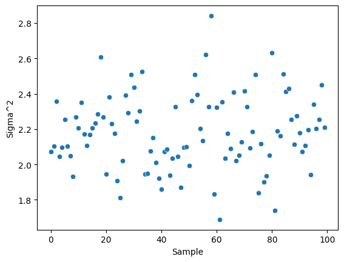

## Scenario 2: Causal Inference

Generate sample data

```python
# RNG
random_seed = 101
rng = np.random.default_rng(random_seed)

# Generate covariates and basis
n = 500
p_X = 5
X = rng.uniform(0, 1, (n, p_X))
pi_X = 0.35 + 0.3 * X[:, 0]
Z = rng.binomial(1, pi_X, n).astype(float)

# Define the outcome mean functions (prognostic and treatment effects)
mu_X = (pi_X - 0.5) * 30
# tau_X = np.sin(X[:,1]*2*np.pi)
tau_X = X[:, 1] * 2

# Generate outcome
epsilon = rng.normal(0, 1, n)
y = mu_X + tau_X * Z + epsilon

# Standardize outcome
y_bar = np.mean(y)
y_std = np.std(y)
resid = (y - y_bar) / y_std
```

# RNG random_seed = 101 rng = np.random.default_rng(random_seed) # Generate covariates and basis n = 500 p_X = 5 X = rng.uniform(0, 1, (n, p_X)) pi_X = 0.35 + 0.3 * X[:, 0] Z = rng.binomial(1, pi_X, n).astype(float) # Define the outcome mean functions (prognostic and treatment effects) mu_X = (pi_X - 0.5) * 30 # tau_X = np.sin(X[:,1]*2*np.pi) tau_X = X[:, 1] * 2 # Generate outcome epsilon = rng.normal(0, 1, n) y = mu_X + tau_X * Z + epsilon # Standardize outcome y_bar = np.mean(y) y_std = np.std(y) resid = (y - y_bar) / y_std

Set some sampling parameters

```python
# Prognostic forest parameters
alpha_mu = 0.95
beta_mu = 2.0
min_samples_leaf_mu = 1
max_depth_mu = -1
num_trees_mu = 200
cutpoint_grid_size_mu = 100
tau_init_mu = 1 / num_trees_mu
leaf_prior_scale_mu = np.array([[tau_init_mu]], order="C")
a_leaf_mu = 3.0
b_leaf_mu = 1 / num_trees_mu
leaf_regression_mu = False
feature_types_mu = np.repeat(0, p_X + 1).astype(int)  # 0 = numeric
var_weights_mu = np.repeat(1 / (p_X + 1), p_X + 1)
leaf_model_mu = 0
leaf_dimension_mu = 1

# Treatment forest parameters
alpha_tau = 0.75
beta_tau = 3.0
min_samples_leaf_tau = 1
max_depth_tau = -1
num_trees_tau = 100
cutpoint_grid_size_tau = 100
tau_init_tau = 1 / num_trees_tau
leaf_prior_scale_tau = np.array([[tau_init_tau]], order="C")
a_leaf_tau = 3.0
b_leaf_tau = 1 / num_trees_tau
leaf_regression_tau = True
feature_types_tau = np.repeat(0, p_X).astype(int)  # 0 = numeric
var_weights_tau = np.repeat(1 / p_X, p_X)
leaf_model_tau = 1
leaf_dimension_tau = 1

# Global parameters
a_global = 2.0
b_global = 1.0
global_variance_init = 1.0
```

# Prognostic forest parameters alpha_mu = 0.95 beta_mu = 2.0 min_samples_leaf_mu = 1 max_depth_mu = -1 num_trees_mu = 200 cutpoint_grid_size_mu = 100 tau_init_mu = 1 / num_trees_mu leaf_prior_scale_mu = np.array([[tau_init_mu]], order="C") a_leaf_mu = 3.0 b_leaf_mu = 1 / num_trees_mu leaf_regression_mu = False feature_types_mu = np.repeat(0, p_X + 1).astype(int) # 0 = numeric var_weights_mu = np.repeat(1 / (p_X + 1), p_X + 1) leaf_model_mu = 0 leaf_dimension_mu = 1 # Treatment forest parameters alpha_tau = 0.75 beta_tau = 3.0 min_samples_leaf_tau = 1 max_depth_tau = -1 num_trees_tau = 100 cutpoint_grid_size_tau = 100 tau_init_tau = 1 / num_trees_tau leaf_prior_scale_tau = np.array([[tau_init_tau]], order="C") a_leaf_tau = 3.0 b_leaf_tau = 1 / num_trees_tau leaf_regression_tau = True feature_types_tau = np.repeat(0, p_X).astype(int) # 0 = numeric var_weights_tau = np.repeat(1 / p_X, p_X) leaf_model_tau = 1 leaf_dimension_tau = 1 # Global parameters a_global = 2.0 b_global = 1.0 global_variance_init = 1.0

Convert data from numpy to `StochTree` representation

```python
# Prognostic Forest Dataset (covariates)
dataset_mu = Dataset()
dataset_mu.add_covariates(np.c_[X, pi_X])

# Treatment Forest Dataset (covariates and treatment variable)
dataset_tau = Dataset()
dataset_tau.add_covariates(X)
dataset_tau.add_basis(Z)

# Residual
residual = Residual(resid)
```

# Prognostic Forest Dataset (covariates) dataset_mu = Dataset() dataset_mu.add_covariates(np.c_[X, pi_X]) # Treatment Forest Dataset (covariates and treatment variable) dataset_tau = Dataset() dataset_tau.add_covariates(X) dataset_tau.add_basis(Z) # Residual residual = Residual(resid)

Initialize tracking and sampling classes

```python
# Global classes
global_model_config = GlobalModelConfig(global_error_variance=global_variance_init)
cpp_rng = RNG(random_seed)
global_var_model = GlobalVarianceModel()

# Prognostic forest sampling classes
forest_container_mu = ForestContainer(num_trees_mu, 1, True, False)
active_forest_mu = Forest(num_trees_mu, 1, True, False)
forest_model_config_mu = ForestModelConfig(
    num_trees=num_trees_mu,
    num_features=p_X + 1,
    num_observations=n,
    feature_types=feature_types_mu,
    variable_weights=var_weights_mu,
    leaf_dimension=leaf_dimension_mu,
    alpha=alpha_mu,
    beta=beta_mu,
    min_samples_leaf=min_samples_leaf_mu,
    max_depth=max_depth_mu,
    leaf_model_type=leaf_model_mu,
    leaf_model_scale=leaf_prior_scale_mu,
    cutpoint_grid_size=cutpoint_grid_size_mu,
)
forest_sampler_mu = ForestSampler(
    dataset_mu,
    global_model_config,
    forest_model_config_mu
)
leaf_var_model_mu = LeafVarianceModel()

# Treatment forest sampling classes
forest_container_tau = ForestContainer(
    num_trees_tau, 1 if np.ndim(Z) == 1 else Z.shape[1], False, False
)
active_forest_tau = Forest(
    num_trees_tau, 1 if np.ndim(Z) == 1 else Z.shape[1], False, False
)
forest_model_config_tau = ForestModelConfig(
    num_trees=num_trees_tau,
    num_features=p_X,
    num_observations=n,
    feature_types=feature_types_tau,
    variable_weights=var_weights_tau,
    leaf_dimension=leaf_dimension_tau,
    alpha=alpha_tau,
    beta=beta_tau,
    min_samples_leaf=min_samples_leaf_tau,
    max_depth=max_depth_tau,
    leaf_model_type=leaf_model_tau,
    leaf_model_scale=leaf_prior_scale_tau,
    cutpoint_grid_size=cutpoint_grid_size_tau,
)
forest_sampler_tau = ForestSampler(
    dataset_tau,
    global_model_config,
    forest_model_config_tau
)
leaf_var_model_tau = LeafVarianceModel()
```

# Global classes global_model_config = GlobalModelConfig(global_error_variance=global_variance_init) cpp_rng = RNG(random_seed) global_var_model = GlobalVarianceModel() # Prognostic forest sampling classes forest_container_mu = ForestContainer(num_trees_mu, 1, True, False) active_forest_mu = Forest(num_trees_mu, 1, True, False) forest_model_config_mu = ForestModelConfig( num_trees=num_trees_mu, num_features=p_X + 1, num_observations=n, feature_types=feature_types_mu, variable_weights=var_weights_mu, leaf_dimension=leaf_dimension_mu, alpha=alpha_mu, beta=beta_mu, min_samples_leaf=min_samples_leaf_mu, max_depth=max_depth_mu, leaf_model_type=leaf_model_mu, leaf_model_scale=leaf_prior_scale_mu, cutpoint_grid_size=cutpoint_grid_size_mu, ) forest_sampler_mu = ForestSampler( dataset_mu, global_model_config, forest_model_config_mu ) leaf_var_model_mu = LeafVarianceModel() # Treatment forest sampling classes forest_container_tau = ForestContainer( num_trees_tau, 1 if np.ndim(Z) == 1 else Z.shape[1], False, False ) active_forest_tau = Forest( num_trees_tau, 1 if np.ndim(Z) == 1 else Z.shape[1], False, False ) forest_model_config_tau = ForestModelConfig( num_trees=num_trees_tau, num_features=p_X, num_observations=n, feature_types=feature_types_tau, variable_weights=var_weights_tau, leaf_dimension=leaf_dimension_tau, alpha=alpha_tau, beta=beta_tau, min_samples_leaf=min_samples_leaf_tau, max_depth=max_depth_tau, leaf_model_type=leaf_model_tau, leaf_model_scale=leaf_prior_scale_tau, cutpoint_grid_size=cutpoint_grid_size_tau, ) forest_sampler_tau = ForestSampler( dataset_tau, global_model_config, forest_model_config_tau ) leaf_var_model_tau = LeafVarianceModel()

Initialize the leaves of the prognostic and treatment forests

```python
init_mu = np.array([np.squeeze(np.mean(resid))])
forest_sampler_mu.prepare_for_sampler(
    dataset_mu,
    residual,
    active_forest_mu,
    leaf_model_mu,
    init_mu,
)

init_tau = np.array([0.0])
forest_sampler_tau.prepare_for_sampler(
    dataset_tau,
    residual,
    active_forest_tau,
    leaf_model_tau,
    init_tau,
)
```

init_mu = np.array([np.squeeze(np.mean(resid))]) forest_sampler_mu.prepare_for_sampler( dataset_mu, residual, active_forest_mu, leaf_model_mu, init_mu, ) init_tau = np.array([0.0]) forest_sampler_tau.prepare_for_sampler( dataset_tau, residual, active_forest_tau, leaf_model_tau, init_tau, )

Prepare to run the sampler

```python
num_warmstart = 10
num_mcmc = 100
num_samples = num_warmstart + num_mcmc
global_var_samples = np.empty(num_samples)
leaf_scale_samples_mu = np.empty(num_samples)
leaf_scale_samples_tau = np.empty(num_samples)
leaf_prior_scale_mu = np.array([[tau_init_mu]])
leaf_prior_scale_tau = np.array([[tau_init_tau]])
current_b0 = -0.5
current_b1 = 0.5
b_0_samples = np.empty(num_samples)
b_1_samples = np.empty(num_samples)
tau_basis = (1 - Z) * current_b0 + Z * current_b1
dataset_tau.update_basis(tau_basis)
```

num_warmstart = 10 num_mcmc = 100 num_samples = num_warmstart + num_mcmc global_var_samples = np.empty(num_samples) leaf_scale_samples_mu = np.empty(num_samples) leaf_scale_samples_tau = np.empty(num_samples) leaf_prior_scale_mu = np.array([[tau_init_mu]]) leaf_prior_scale_tau = np.array([[tau_init_tau]]) current_b0 = -0.5 current_b1 = 0.5 b_0_samples = np.empty(num_samples) b_1_samples = np.empty(num_samples) tau_basis = (1 - Z) * current_b0 + Z * current_b1 dataset_tau.update_basis(tau_basis)

Run the "grow-from-root" (XBART) sampler

```python
for i in range(num_warmstart):
    # Sample the prognostic forest
    forest_sampler_mu.sample_one_iteration(
        forest_container_mu,
        active_forest_mu,
        dataset_mu,
        residual,
        cpp_rng,
        global_model_config,
        forest_model_config_mu,
        True,
        True,
    )
    # Sample global variance
    current_sigma2 = global_var_model.sample_one_iteration(
        residual, cpp_rng, a_global, b_global
    )
    global_model_config.update_global_error_variance(current_sigma2)
    # Sample prognostic forest leaf scale
    leaf_prior_scale_mu[0, 0] = leaf_var_model_mu.sample_one_iteration(
        active_forest_mu, cpp_rng, a_leaf_mu, b_leaf_mu
    )
    leaf_scale_samples_mu[i] = leaf_prior_scale_mu[0, 0]
    forest_model_config_mu.update_leaf_model_scale(
        leaf_prior_scale_mu
    )

    # Sample the treatment effect forest
    forest_sampler_tau.sample_one_iteration(
        forest_container_tau,
        active_forest_tau,
        dataset_tau,
        residual,
        cpp_rng,
        global_model_config,
        forest_model_config_tau,
        True,
        True,
    )

    # Sample adaptive coding parameters
    mu_x = active_forest_mu.predict_raw(dataset_mu)
    tau_x = np.squeeze(active_forest_tau.predict_raw(dataset_tau))
    s_tt0 = np.sum(tau_x * tau_x * (Z == 0))
    s_tt1 = np.sum(tau_x * tau_x * (Z == 1))
    partial_resid_mu = resid - np.squeeze(mu_x)
    s_ty0 = np.sum(tau_x * partial_resid_mu * (Z == 0))
    s_ty1 = np.sum(tau_x * partial_resid_mu * (Z == 1))
    current_b0 = rng.normal(
        loc=(s_ty0 / (s_tt0 + 2 * current_sigma2)),
        scale=np.sqrt(current_sigma2 / (s_tt0 + 2 * current_sigma2)),
        size=1,
    )[0]
    current_b1 = rng.normal(
        loc=(s_ty1 / (s_tt1 + 2 * current_sigma2)),
        scale=np.sqrt(current_sigma2 / (s_tt1 + 2 * current_sigma2)),
        size=1,
    )[0]
    tau_basis = (1 - Z) * current_b0 + Z * current_b1
    dataset_tau.update_basis(tau_basis)
    forest_sampler_tau.propagate_basis_update(dataset_tau, residual, active_forest_tau)
    b_0_samples[i] = current_b0
    b_1_samples[i] = current_b1

    # Sample global variance
    current_sigma2 = global_var_model.sample_one_iteration(
        residual, cpp_rng, a_global, b_global
    )
    global_model_config.update_global_error_variance(current_sigma2)
    global_var_samples[i] = current_sigma2
    # Sample treatment forest leaf scale
    leaf_prior_scale_tau[0, 0] = leaf_var_model_tau.sample_one_iteration(
        active_forest_tau, cpp_rng, a_leaf_tau, b_leaf_tau
    )
    leaf_scale_samples_tau[i] = leaf_prior_scale_tau[0, 0]
    forest_model_config_tau.update_leaf_model_scale(
        leaf_prior_scale_tau
    )
```

for i in range(num_warmstart): # Sample the prognostic forest forest_sampler_mu.sample_one_iteration( forest_container_mu, active_forest_mu, dataset_mu, residual, cpp_rng, global_model_config, forest_model_config_mu, True, True, ) # Sample global variance current_sigma2 = global_var_model.sample_one_iteration( residual, cpp_rng, a_global, b_global ) global_model_config.update_global_error_variance(current_sigma2) # Sample prognostic forest leaf scale leaf_prior_scale_mu[0, 0] = leaf_var_model_mu.sample_one_iteration( active_forest_mu, cpp_rng, a_leaf_mu, b_leaf_mu ) leaf_scale_samples_mu[i] = leaf_prior_scale_mu[0, 0] forest_model_config_mu.update_leaf_model_scale( leaf_prior_scale_mu ) # Sample the treatment effect forest forest_sampler_tau.sample_one_iteration( forest_container_tau, active_forest_tau, dataset_tau, residual, cpp_rng, global_model_config, forest_model_config_tau, True, True, ) # Sample adaptive coding parameters mu_x = active_forest_mu.predict_raw(dataset_mu) tau_x = np.squeeze(active_forest_tau.predict_raw(dataset_tau)) s_tt0 = np.sum(tau_x * tau_x * (Z == 0)) s_tt1 = np.sum(tau_x * tau_x * (Z == 1)) partial_resid_mu = resid - np.squeeze(mu_x) s_ty0 = np.sum(tau_x * partial_resid_mu * (Z == 0)) s_ty1 = np.sum(tau_x * partial_resid_mu * (Z == 1)) current_b0 = rng.normal( loc=(s_ty0 / (s_tt0 + 2 * current_sigma2)), scale=np.sqrt(current_sigma2 / (s_tt0 + 2 * current_sigma2)), size=1, )[0] current_b1 = rng.normal( loc=(s_ty1 / (s_tt1 + 2 * current_sigma2)), scale=np.sqrt(current_sigma2 / (s_tt1 + 2 * current_sigma2)), size=1, )[0] tau_basis = (1 - Z) * current_b0 + Z * current_b1 dataset_tau.update_basis(tau_basis) forest_sampler_tau.propagate_basis_update(dataset_tau, residual, active_forest_tau) b_0_samples[i] = current_b0 b_1_samples[i] = current_b1 # Sample global variance current_sigma2 = global_var_model.sample_one_iteration( residual, cpp_rng, a_global, b_global ) global_model_config.update_global_error_variance(current_sigma2) global_var_samples[i] = current_sigma2 # Sample treatment forest leaf scale leaf_prior_scale_tau[0, 0] = leaf_var_model_tau.sample_one_iteration( active_forest_tau, cpp_rng, a_leaf_tau, b_leaf_tau ) leaf_scale_samples_tau[i] = leaf_prior_scale_tau[0, 0] forest_model_config_tau.update_leaf_model_scale( leaf_prior_scale_tau )

Run the MCMC (BART) sampler, initialized at the last XBART sample

```python
for i in range(num_warmstart, num_samples):
    # Sample the prognostic forest
    forest_sampler_mu.sample_one_iteration(
        forest_container_mu,
        active_forest_mu,
        dataset_mu,
        residual,
        cpp_rng,
        global_model_config,
        forest_model_config_mu,
        True,
        False,
    )
    # Sample global variance
    current_sigma2 = global_var_model.sample_one_iteration(
        residual, cpp_rng, a_global, b_global
    )
    global_model_config.update_global_error_variance(current_sigma2)
    # Sample prognostic forest leaf scale
    leaf_prior_scale_mu[0, 0] = leaf_var_model_mu.sample_one_iteration(
        active_forest_mu, cpp_rng, a_leaf_mu, b_leaf_mu
    )
    leaf_scale_samples_mu[i] = leaf_prior_scale_mu[0, 0]
    forest_model_config_mu.update_leaf_model_scale(
        leaf_prior_scale_mu
    )

    # Sample the treatment effect forest
    forest_sampler_tau.sample_one_iteration(
        forest_container_tau,
        active_forest_tau,
        dataset_tau,
        residual,
        cpp_rng,
        global_model_config,
        forest_model_config_tau,
        True,
        False,
    )

    # Sample adaptive coding parameters
    mu_x = active_forest_mu.predict_raw(dataset_mu)
    tau_x = np.squeeze(active_forest_tau.predict_raw(dataset_tau))
    s_tt0 = np.sum(tau_x * tau_x * (Z == 0))
    s_tt1 = np.sum(tau_x * tau_x * (Z == 1))
    partial_resid_mu = resid - np.squeeze(mu_x)
    s_ty0 = np.sum(tau_x * partial_resid_mu * (Z == 0))
    s_ty1 = np.sum(tau_x * partial_resid_mu * (Z == 1))
    current_b0 = rng.normal(
        loc=(s_ty0 / (s_tt0 + 2 * current_sigma2)),
        scale=np.sqrt(current_sigma2 / (s_tt0 + 2 * current_sigma2)),
        size=1,
    )[0]
    current_b1 = rng.normal(
        loc=(s_ty1 / (s_tt1 + 2 * current_sigma2)),
        scale=np.sqrt(current_sigma2 / (s_tt1 + 2 * current_sigma2)),
        size=1,
    )[0]
    tau_basis = (1 - Z) * current_b0 + Z * current_b1
    dataset_tau.update_basis(tau_basis)
    forest_sampler_tau.propagate_basis_update(dataset_tau, residual, active_forest_tau)
    b_0_samples[i] = current_b0
    b_1_samples[i] = current_b1

    # Sample global variance
    current_sigma2 = global_var_model.sample_one_iteration(
        residual, cpp_rng, a_global, b_global
    )
    global_model_config.update_global_error_variance(current_sigma2)
    global_var_samples[i] = current_sigma2
    # Sample treatment forest leaf scale
    leaf_prior_scale_tau[0, 0] = leaf_var_model_tau.sample_one_iteration(
        active_forest_tau, cpp_rng, a_leaf_tau, b_leaf_tau
    )
    leaf_scale_samples_tau[i] = leaf_prior_scale_tau[0, 0]
    forest_model_config_tau.update_leaf_model_scale(
        leaf_prior_scale_tau
    )
```

for i in range(num_warmstart, num_samples): # Sample the prognostic forest forest_sampler_mu.sample_one_iteration( forest_container_mu, active_forest_mu, dataset_mu, residual, cpp_rng, global_model_config, forest_model_config_mu, True, False, ) # Sample global variance current_sigma2 = global_var_model.sample_one_iteration( residual, cpp_rng, a_global, b_global ) global_model_config.update_global_error_variance(current_sigma2) # Sample prognostic forest leaf scale leaf_prior_scale_mu[0, 0] = leaf_var_model_mu.sample_one_iteration( active_forest_mu, cpp_rng, a_leaf_mu, b_leaf_mu ) leaf_scale_samples_mu[i] = leaf_prior_scale_mu[0, 0] forest_model_config_mu.update_leaf_model_scale( leaf_prior_scale_mu ) # Sample the treatment effect forest forest_sampler_tau.sample_one_iteration( forest_container_tau, active_forest_tau, dataset_tau, residual, cpp_rng, global_model_config, forest_model_config_tau, True, False, ) # Sample adaptive coding parameters mu_x = active_forest_mu.predict_raw(dataset_mu) tau_x = np.squeeze(active_forest_tau.predict_raw(dataset_tau)) s_tt0 = np.sum(tau_x * tau_x * (Z == 0)) s_tt1 = np.sum(tau_x * tau_x * (Z == 1)) partial_resid_mu = resid - np.squeeze(mu_x) s_ty0 = np.sum(tau_x * partial_resid_mu * (Z == 0)) s_ty1 = np.sum(tau_x * partial_resid_mu * (Z == 1)) current_b0 = rng.normal( loc=(s_ty0 / (s_tt0 + 2 * current_sigma2)), scale=np.sqrt(current_sigma2 / (s_tt0 + 2 * current_sigma2)), size=1, )[0] current_b1 = rng.normal( loc=(s_ty1 / (s_tt1 + 2 * current_sigma2)), scale=np.sqrt(current_sigma2 / (s_tt1 + 2 * current_sigma2)), size=1, )[0] tau_basis = (1 - Z) * current_b0 + Z * current_b1 dataset_tau.update_basis(tau_basis) forest_sampler_tau.propagate_basis_update(dataset_tau, residual, active_forest_tau) b_0_samples[i] = current_b0 b_1_samples[i] = current_b1 # Sample global variance current_sigma2 = global_var_model.sample_one_iteration( residual, cpp_rng, a_global, b_global ) global_model_config.update_global_error_variance(current_sigma2) global_var_samples[i] = current_sigma2 # Sample treatment forest leaf scale leaf_prior_scale_tau[0, 0] = leaf_var_model_tau.sample_one_iteration( active_forest_tau, cpp_rng, a_leaf_tau, b_leaf_tau ) leaf_scale_samples_tau[i] = leaf_prior_scale_tau[0, 0] forest_model_config_tau.update_leaf_model_scale( leaf_prior_scale_tau )

Extract mean function and error variance posterior samples

```python
# Forest predictions
forest_preds_mu = forest_container_mu.predict(dataset_mu) * y_std + y_bar
forest_preds_mu_gfr = forest_preds_mu[:, :num_warmstart]
forest_preds_mu_mcmc = forest_preds_mu[:, num_warmstart:num_samples]
treatment_coding_samples = b_1_samples - b_0_samples
forest_preds_tau = (
    forest_container_tau.predict_raw(dataset_tau)
    * y_std
    * np.expand_dims(treatment_coding_samples, axis=(0, 2))
)
forest_preds_tau_gfr = forest_preds_tau[:, :num_warmstart]
forest_preds_tau_mcmc = forest_preds_tau[:, num_warmstart:num_samples]

# Global error variance
sigma2_samples = global_var_samples * y_std * y_std
sigma2_samples_gfr = sigma2_samples[:num_warmstart]
sigma2_samples_mcmc = sigma2_samples[num_warmstart:num_samples]

# Adaptive coding parameters
b_1_samples_gfr = b_1_samples[:num_warmstart] * y_std
b_0_samples_gfr = b_0_samples[:num_warmstart] * y_std
b_1_samples_mcmc = b_1_samples[num_warmstart:] * y_std
b_0_samples_mcmc = b_0_samples[num_warmstart:] * y_std
```

# Forest predictions forest_preds_mu = forest_container_mu.predict(dataset_mu) * y_std + y_bar forest_preds_mu_gfr = forest_preds_mu[:, :num_warmstart] forest_preds_mu_mcmc = forest_preds_mu[:, num_warmstart:num_samples] treatment_coding_samples = b_1_samples - b_0_samples forest_preds_tau = ( forest_container_tau.predict_raw(dataset_tau) * y_std * np.expand_dims(treatment_coding_samples, axis=(0, 2)) ) forest_preds_tau_gfr = forest_preds_tau[:, :num_warmstart] forest_preds_tau_mcmc = forest_preds_tau[:, num_warmstart:num_samples] # Global error variance sigma2_samples = global_var_samples * y_std * y_std sigma2_samples_gfr = sigma2_samples[:num_warmstart] sigma2_samples_mcmc = sigma2_samples[num_warmstart:num_samples] # Adaptive coding parameters b_1_samples_gfr = b_1_samples[:num_warmstart] * y_std b_0_samples_gfr = b_0_samples[:num_warmstart] * y_std b_1_samples_mcmc = b_1_samples[num_warmstart:] * y_std b_0_samples_mcmc = b_0_samples[num_warmstart:] * y_std

Inspect the GFR (XBART) samples

```python
forest_preds_tau_avg_gfr = np.squeeze(forest_preds_tau_gfr).mean(axis=1, keepdims=True)
forest_pred_tau_df_gfr = pd.DataFrame(
    np.concatenate((np.expand_dims(tau_X, 1), forest_preds_tau_avg_gfr), axis=1),
    columns=["True tau", "Average estimated tau"],
)
sns.scatterplot(data=forest_pred_tau_df_gfr, x="True tau", y="Average estimated tau")
plt.axline((0, 0), slope=1, color="black", linestyle=(0, (3, 3)))
plt.show()
```

forest_preds_tau_avg_gfr = np.squeeze(forest_preds_tau_gfr).mean(axis=1, keepdims=True) forest_pred_tau_df_gfr = pd.DataFrame( np.concatenate((np.expand_dims(tau_X, 1), forest_preds_tau_avg_gfr), axis=1), columns=["True tau", "Average estimated tau"], ) sns.scatterplot(data=forest_pred_tau_df_gfr, x="True tau", y="Average estimated tau") plt.axline((0, 0), slope=1, color="black", linestyle=(0, (3, 3))) plt.show()

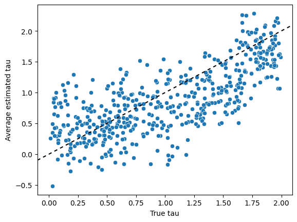

```python
forest_pred_avg_gfr = np.squeeze(forest_preds_mu_gfr).mean(axis=1, keepdims=True)
forest_pred_df_gfr = pd.DataFrame(
    np.concatenate((np.expand_dims(mu_X, 1), forest_pred_avg_gfr), axis=1),
    columns=["True mu", "Average estimated mu"],
)
sns.scatterplot(data=forest_pred_df_gfr, x="True mu", y="Average estimated mu")
plt.axline((0, 0), slope=1, color="black", linestyle=(0, (3, 3)))
plt.show()
```

forest_pred_avg_gfr = np.squeeze(forest_preds_mu_gfr).mean(axis=1, keepdims=True) forest_pred_df_gfr = pd.DataFrame( np.concatenate((np.expand_dims(mu_X, 1), forest_pred_avg_gfr), axis=1), columns=["True mu", "Average estimated mu"], ) sns.scatterplot(data=forest_pred_df_gfr, x="True mu", y="Average estimated mu") plt.axline((0, 0), slope=1, color="black", linestyle=(0, (3, 3))) plt.show()

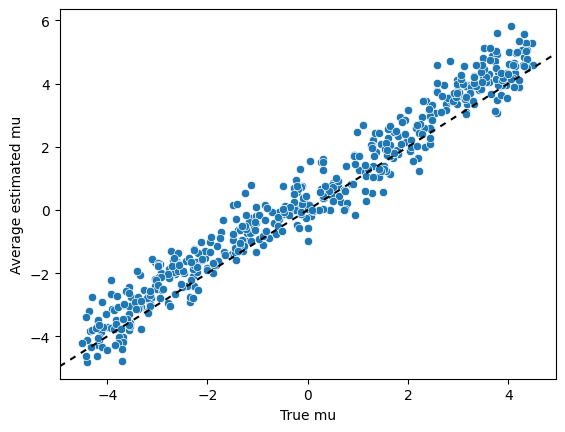

```python
sigma_df_gfr = pd.DataFrame(
    np.concatenate(
        (
            np.expand_dims(np.arange(num_warmstart), axis=1),
            np.expand_dims(sigma2_samples_gfr, axis=1),
        ),
        axis=1,
    ),
    columns=["Sample", "Sigma^2"],
)
sns.scatterplot(data=sigma_df_gfr, x="Sample", y="Sigma^2")
plt.show()
```

sigma_df_gfr = pd.DataFrame( np.concatenate( ( np.expand_dims(np.arange(num_warmstart), axis=1), np.expand_dims(sigma2_samples_gfr, axis=1), ), axis=1, ), columns=["Sample", "Sigma^2"], ) sns.scatterplot(data=sigma_df_gfr, x="Sample", y="Sigma^2") plt.show()

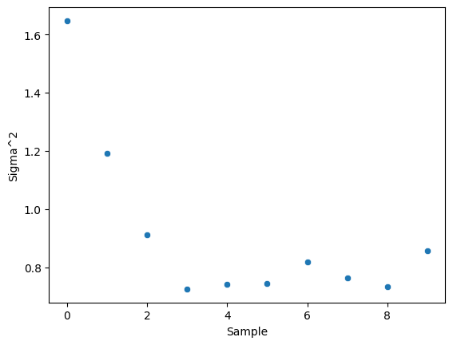

```python
b_df_gfr = pd.DataFrame(
    np.concatenate(
        (
            np.expand_dims(np.arange(num_warmstart), axis=1),
            np.expand_dims(b_0_samples_gfr, axis=1),
            np.expand_dims(b_1_samples_gfr, axis=1),
        ),
        axis=1,
    ),
    columns=["Sample", "Beta_0", "Beta_1"],
)
sns.scatterplot(data=b_df_gfr, x="Sample", y="Beta_0")
sns.scatterplot(data=b_df_gfr, x="Sample", y="Beta_1")
plt.show()
```

b_df_gfr = pd.DataFrame( np.concatenate( ( np.expand_dims(np.arange(num_warmstart), axis=1), np.expand_dims(b_0_samples_gfr, axis=1), np.expand_dims(b_1_samples_gfr, axis=1), ), axis=1, ), columns=["Sample", "Beta_0", "Beta_1"], ) sns.scatterplot(data=b_df_gfr, x="Sample", y="Beta_0") sns.scatterplot(data=b_df_gfr, x="Sample", y="Beta_1") plt.show()

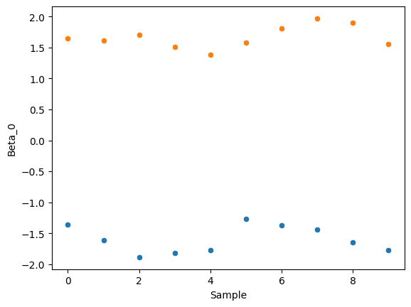

Inspect the MCMC (BART) samples

```python
forest_pred_avg_mcmc = np.squeeze(forest_preds_tau_mcmc).mean(axis=1, keepdims=True)
forest_pred_df_mcmc = pd.DataFrame(
    np.concatenate((np.expand_dims(tau_X, 1), forest_pred_avg_mcmc), axis=1),
    columns=["True tau", "Average estimated tau"],
)
sns.scatterplot(data=forest_pred_df_mcmc, x="True tau", y="Average estimated tau")
plt.axline((0, 0), slope=1, color="black", linestyle=(0, (3, 3)))
plt.show()
```

forest_pred_avg_mcmc = np.squeeze(forest_preds_tau_mcmc).mean(axis=1, keepdims=True) forest_pred_df_mcmc = pd.DataFrame( np.concatenate((np.expand_dims(tau_X, 1), forest_pred_avg_mcmc), axis=1), columns=["True tau", "Average estimated tau"], ) sns.scatterplot(data=forest_pred_df_mcmc, x="True tau", y="Average estimated tau") plt.axline((0, 0), slope=1, color="black", linestyle=(0, (3, 3))) plt.show()

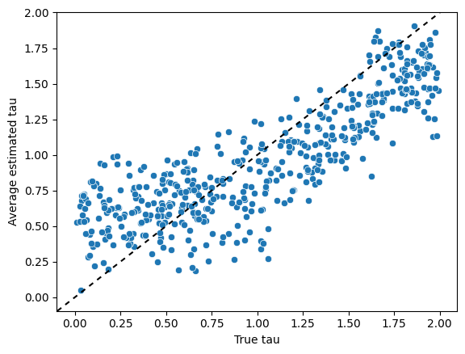

```python
forest_pred_avg_mcmc = np.squeeze(forest_preds_mu_mcmc).mean(axis=1, keepdims=True)
forest_pred_df_mcmc = pd.DataFrame(
    np.concatenate((np.expand_dims(mu_X, 1), forest_pred_avg_mcmc), axis=1),
    columns=["True mu", "Average estimated mu"],
)
sns.scatterplot(data=forest_pred_df_mcmc, x="True mu", y="Average estimated mu")
plt.axline((0, 0), slope=1, color="black", linestyle=(0, (3, 3)))
plt.show()
```

forest_pred_avg_mcmc = np.squeeze(forest_preds_mu_mcmc).mean(axis=1, keepdims=True) forest_pred_df_mcmc = pd.DataFrame( np.concatenate((np.expand_dims(mu_X, 1), forest_pred_avg_mcmc), axis=1), columns=["True mu", "Average estimated mu"], ) sns.scatterplot(data=forest_pred_df_mcmc, x="True mu", y="Average estimated mu") plt.axline((0, 0), slope=1, color="black", linestyle=(0, (3, 3))) plt.show()

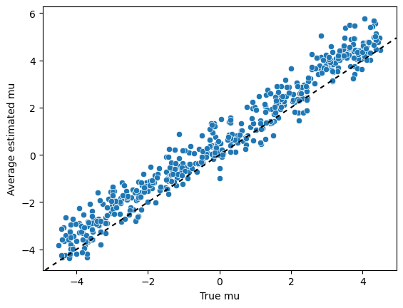

```python
sigma_df_mcmc = pd.DataFrame(
    np.concatenate(
        (
            np.expand_dims(np.arange(num_samples - num_warmstart), axis=1),
            np.expand_dims(sigma2_samples_mcmc, axis=1),
        ),
        axis=1,
    ),
    columns=["Sample", "Sigma^2"],
)
sns.scatterplot(data=sigma_df_mcmc, x="Sample", y="Sigma^2")
plt.show()
```

sigma_df_mcmc = pd.DataFrame( np.concatenate( ( np.expand_dims(np.arange(num_samples - num_warmstart), axis=1), np.expand_dims(sigma2_samples_mcmc, axis=1), ), axis=1, ), columns=["Sample", "Sigma^2"], ) sns.scatterplot(data=sigma_df_mcmc, x="Sample", y="Sigma^2") plt.show()

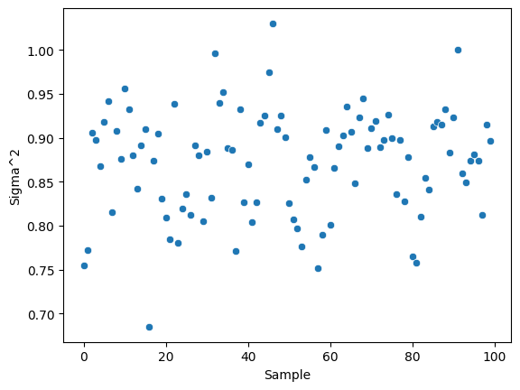

```python
b_df_mcmc = pd.DataFrame(
    np.concatenate(
        (
            np.expand_dims(np.arange(num_samples - num_warmstart), axis=1),
            np.expand_dims(b_0_samples_mcmc, axis=1),
            np.expand_dims(b_1_samples_mcmc, axis=1),
        ),
        axis=1,
    ),
    columns=["Sample", "Beta_0", "Beta_1"],
)
sns.scatterplot(data=b_df_mcmc, x="Sample", y="Beta_0")
sns.scatterplot(data=b_df_mcmc, x="Sample", y="Beta_1")
plt.show()
```

b_df_mcmc = pd.DataFrame( np.concatenate( ( np.expand_dims(np.arange(num_samples - num_warmstart), axis=1), np.expand_dims(b_0_samples_mcmc, axis=1), np.expand_dims(b_1_samples_mcmc, axis=1), ), axis=1, ), columns=["Sample", "Beta_0", "Beta_1"], ) sns.scatterplot(data=b_df_mcmc, x="Sample", y="Beta_0") sns.scatterplot(data=b_df_mcmc, x="Sample", y="Beta_1") plt.show()

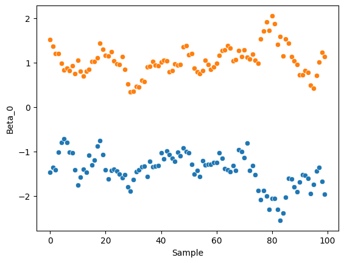

# References

Murray, Jared S. "Log-linear Bayesian additive regression trees for multinomial logistic and count regression models." Journal of the American Statistical Association 116, no. 534 (2021): 756-769.

Hahn, P. Richard, Jared S. Murray, and Carlos M. Carvalho. "Bayesian regression tree models for causal inference: Regularization, confounding, and heterogeneous effects (with discussion)." Bayesian Analysis 15, no. 3 (2020): 965-1056.